# Solving 538's Riddler about Free Throws

The question is was posted in early Septermber, 2017, **[here](https://fivethirtyeight.com/features/is-your-friend-full-of-it/)** and is a undergraduate level probabilty problem:

> You’re hanging out with some friends, shooting the breeze and talking sports. One of them brags to the group that he once made 17 free throws in a row after years of not having touched a basketball. You think the claim sounds unlikely, but plausible. Another friend scoffs, thinking it completely impossible. Let’s give your bragging friend the benefit of the doubt and say he’s a 70-percent free-throw shooter.

> So, who’s right? What is the number of free throws that a 70-percent shooter would be expected to take before having a streak of 17 makes in a row? And what if his accuracy was a bit worse?

This lends itself to a binomial probability distribution. The shooter has a 70% chance of making and a 30% chance of missing any given free throw. It should be immediate that for the shooter to make 17/17 the probability would be $$\underbrace{(0.7)*(0.7)...*(0.7)}_{17 \text{ times}} = 0.0023$$ This is roughly a 0.2% chance that the shooter will make 17 in a row while taking 17 shots.

*But that's not the question...*

We want the expected number of attempts until the shooter hits a streak of 17 in a row.

# Expected Values

Let's look at a similar problem that is a bit easier to wrap our heads around. I could ask how many times would I need to flip a coin before I got a streak of two heads. Clearly the probability of getting two heads in a row is (0.5)*(0.5) = 0.25, or 25%.

The event we are concerned with is the event that we get two heads in a row. This is unknown so let's represent it with a variable, **X**. Let's say the first flip is a tails, which happens with a probability of 1/2, and is one wasted flip, so now we need **X + 1** flips to get a streak of two heads.

Suppose that the first flip was heads but the second flip was tails. This happens with proabbility 1/4 and we have two wasted flips so we now need **X + 2** further flips.

The only other possibility is that the two flips were both heads, which happens with probability 1/4 and took 2 flips. Summing these up we have

> **X** = (1/2)(**X+1**) + (1/4)(**X + 2**) + (1/4)2

Or **X = 6**. That is, on average, you should expect to get a streak of 2 heads every 6 flips.

Generalizing this, for the *k*-th flip to be tails the number of flips would be $$\frac{1}{2^k}(x + k)$$, and one can deduce the expected number of flips to get a streak of **N** heads would be $$X = 2^{N+1} - 2$$

## *What if it's not a fair coin?*

Let's start with two flips again and let's assume the head comes up with a 70% chance and tails only 30%. Let **X** be the number of flips needed to get a streak of two heads.

If the first flip is a tail, that happens with a probability of 0.3 and we have wasted a flip so now we need **X + 1** flips. If the first flip is a head, but the second flip is a tail, that happens with a probability of (0.7)(0.3) and we need **X + 2** flips. If two consecutive flips are heads, which happen with probabilty (0.7)(0.7) we acheived success in two flips. Now our equation looks like:

> **X** = (0.3)(**X+1**) + (0.7)(0.3)(**X + 2**) + (0.7)(0.7)2

Solving for **X** we get $$X \approx 3.469$$

If let **X** now be 3 heads in a row, we go through the same analysis and end up with an equation that looks like

> **X** = (0.3)(**X+1**) + (0.7)(0.3)(**X + 2**) + (0.7)(0.7)(0.3)(**X + 3**) + (0.7)(0.7)(0.7)3

and solving for **X** we get that it takes approximately 6.38 flips.

In general, if we let *a = probability of heads*, then *(1 - a) = probability of tails* and if we look for a streak of **X = 3** heads the equation above becomes,

$$X = (1-a)(X+1) + (1-a)(a)(X + 2) + (1-a)(a^2)(X + 3) + a^33$$

More generally, the expected number of flips to get **N** heads is $$ X = (1-a)\sum_{k=1}^Na^{k-1}(X + k) + a^NN$$ and solving for **X** we have a nice tidy formula, $$X = \frac{(1-a)\sum_{k=1}^Nka^{k-1} + a^NN}{1 - (1 - a)\sum_{k=1}^Na^{k-1}}$$

```python
import numpy as np
import pandas as pd

import matplotlib.pyplot as plt
%matplotlib inline

def get_expected_value(a,N):
    # this method returns the expected number
    # of flips, free throws or whatever

    num = (1 - a)*np.sum([k*a**(k-1) for k in range(1,N+1)]) + a**N*N
    den = 1 - (1-a)*np.sum([a**(k-1) for k in range(1,N+1)])

    return num/den

def hours_and_minutes_to_acieve(attempts):
    s = 11.0 # assume 11 seconds per free throw

    return s*attempts/60.0/60.0
```

```python
# test it

print(get_expected_value(0.5,2)) # should be 6
print(get_expected_value(0.7,2)) # should be 3.469
```

```
6.0
3.4693877551
```

```python
# Free throws:
print("The expected number of free throws \n\
for a 70% free throw shooter to hit 17 in a row is ...\n")
print(int(get_expected_value(0.7,17)),"attempts")
```

```
The expected number of free throws
for a 70% free throw shooter to hit 17 in a row is ...

1429 attempts
```

# How long was he in the gym?

So, let's say, on average it takes 11 seconds to take a free throw and recover your miss/make. Your buddy would, on average, spent 11$\times$1429 seconds or about **4 hours and 22 minutes** to acieve this.

```python
print("The length, in hours, to hit 17 in a row:",hours_and_minutes_to_acieve(1429))
```

```
The length, in hours, to hit 17 in a row: 4.366388888888889
```

```python
# for fun let's see how long it would take varous free throw shooters
percentage = [40 + i for i in range(54)] # reasonable range

shooting_info = pd.DataFrame(columns=['expected attempts','time'],index=percentage)
```

```python
atts = []
times = []
for val in shooting_info.index:
    attempts = get_expected_value(val*.01,17)
    atts.append(attempts)
    times.append(hours_and_minutes_to_acieve(attempts))
shooting_info['time'] = times
shooting_info['expected attempts'] = atts
```

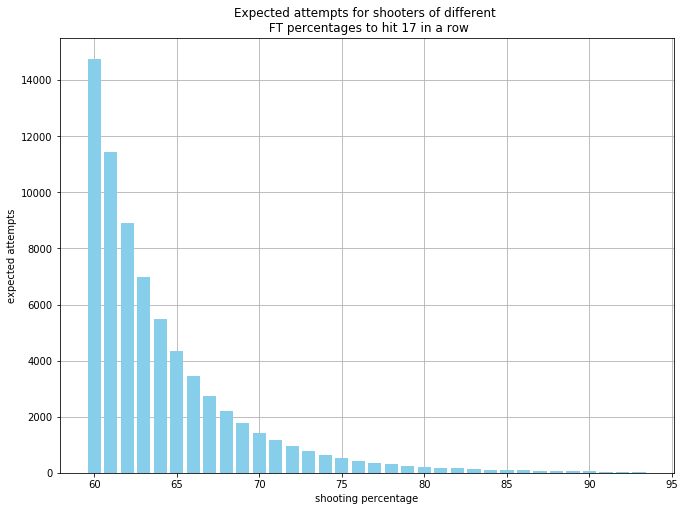

```python
fig = plt.figure(figsize=(11,8))
plt.grid(zorder=0)
plt.bar(shooting_info['expected attempts'][20:].index,shooting_info['expected attempts'][20:],
       align='center', color='skyblue', zorder=3)
plt.title('Expected attempts for shooters of different \n FT percentages to hit 17 in a row')
plt.xlabel('shooting percentage')
plt.ylabel('expected attempts');
```

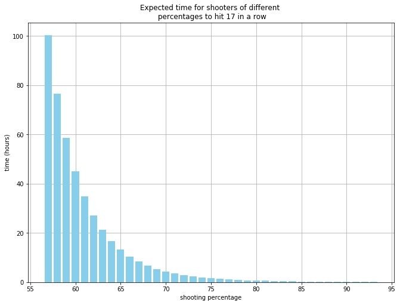

```python
fig = plt.figure(figsize=(11,8))
plt.grid(zorder=0)
plt.bar(shooting_info['time'][17:].index,shooting_info['time'][17:],
       align='center', color='skyblue', zorder=3)
plt.title('Expected time for shooters of different \n percentages to hit 17 in a row')
plt.xlabel('shooting percentage')
plt.ylabel('time (hours)');
```